# machLearnProject

Crazy88

Sunday, November 08, 2015

#### Executive Summary

**Background (directly from assignment)**

Using devices such as Jawbone Up, Nike FuelBand, and Fitbit it is now possible to collect a large amount of data about personal activity relatively inexpensively. These type of devices are part of the quantified self movement - a group of enthusiasts who take measurements about themselves regularly to improve their health, to find patterns in their behavior, or because they are tech geeks. One thing that people regularly do is quantify how much of a particular activity they do, but they rarely quantify how well they do it. In this project, your goal will be to use data from accelerometers on the belt, forearm, arm, and dumbell of 6 participants. They were asked to perform barbell lifts correctly and incorrectly in 5 different ways. More information is available from the website here: http://groupware.les.inf.puc-rio.br/har (see the section on the Weight Lifting Exercise Dataset).

**Data (directly from assignment)**

The training data for this project are available here:

https://d396qusza40orc.cloudfront.net/predmachlearn/pml-training.csv

The test data are available here:

https://d396qusza40orc.cloudfront.net/predmachlearn/pml-testing.csv

The data for this project come from this source: http://groupware.les.inf.puc-rio.br/har.

**Approach**

Cleanse the data, and split into training and testing data sets. Create three models with the training data: decision tree, random forests and boosting. Select the most accurate model, and cross-validate with the testing data to determine the out of sample error rate. The “best” model is random forests, which validates 20/20 of the submitted test cases.

#### Load and Cleanse the Data

Set the seed. Read the csv files into R. Naming the testing data “the20” so as to not confuse this with the 40% sample testing data I create later for cross-validation. Note: I previously downloaded these, my company firewall won’t allow me to automate the download.

```r
set.seed(1234)
raw<-read.csv(file="pml-training.csv", header=TRUE, sep=",")
the20<-read.csv(file="pml-testing.csv", header=TRUE, sep=",")
```

Remove N/A, low variance, unneeded. Factor classe.

```r
# remove variables with high proportion of NA
NAs<-sapply(raw,is.na)
TotNAs<-colSums(NAs)
percentNAs<-TotNAs/(dim(raw)[1])
#viewed percentNAs, determine cutoff
delete<-percentNAs>=.8
#keep columns that shouldn't be deleted
raw<-raw[,!delete]

#eliminate low variance variables
nzv<-nearZeroVar(raw,saveMetrics=TRUE)
raw<-raw[,nzv$nzv==FALSE]

#eliminate unneeded variables
delete2<-names(raw) %in%
c(
        'X',
        'user_name',
        'raw_timestamp_part_1',
        'raw_timestamp_part_2',
        'num_window',
        'cvtd_timestamp'
)
raw<-raw[,!delete2]

#factor classe
raw$classe<-factor(raw$classe)
```

Now, split into testing and training datasets

```r
inTrain=createDataPartition(y=raw$classe,p=0.6,list=FALSE)
training=raw[inTrain,]
testing=raw[-inTrain,]
```

#### Decision Tree

Build with caret’s rpart method and the training dataset.

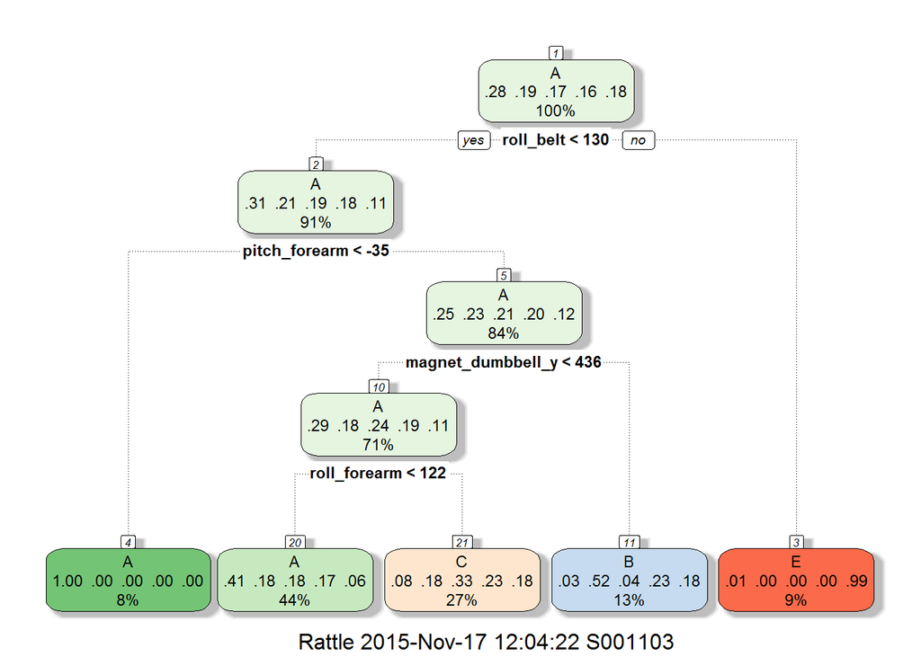

```r
#random forest - train
modFitTree<-train(classe~.,method="rpart",data=training)
fancyRpartPlot(modFitTree$finalModel)
```

```r
predictTree<-predict(modFitTree,newdata=training)
conMatrixTree<-confusionMatrix(predictTree,training$classe)
conMatrixTree
```

```
## Confusion Matrix and Statistics
##
##           Reference
## Prediction    A    B    C    D    E
##          A 3032  910  941  861  312
##          B   51  798   60  348  284
##          C  255  571 1053  721  577
##          D    0    0    0    0    0
##          E   10    0    0    0  992
##
## Overall Statistics
##
##                Accuracy : 0.4989
##                  95% CI : (0.4898, 0.508)
##     No Information Rate : 0.2843
##     P-Value [Acc > NIR] : < 2.2e-16
##
##                   Kappa : 0.3456
##  Mcnemar's Test P-Value : NA
##
## Statistics by Class:
##
##                      Class: A Class: B Class: C Class: D Class: E
## Sensitivity            0.9056  0.35015  0.51266   0.0000  0.45820
## Specificity            0.6412  0.92176  0.78153   1.0000  0.99896
## Pos Pred Value         0.5007  0.51785  0.33144      NaN  0.99002
## Neg Pred Value         0.9448  0.85530  0.88359   0.8361  0.89113
## Prevalence             0.2843  0.19353  0.17442   0.1639  0.18385
## Detection Rate         0.2575  0.06776  0.08942   0.0000  0.08424
## Detection Prevalence   0.5143  0.13086  0.26979   0.0000  0.08509
## Balanced Accuracy      0.7734  0.63596  0.64709   0.5000  0.72858
```

#### Random Forests

Build with randomForest and the training dataset. Chose not to use caret’s rf method, as it runs very slowly on my machine.

```r
#random forest - train
modFitRF<-randomForest(classe~.,data=training)
predictRF<-predict(modFitRF,newdata=training)
conMatrixRF<-confusionMatrix(predictRF,training$classe)
conMatrixRF
```

```
## Confusion Matrix and Statistics
##
##           Reference
## Prediction    A    B    C    D    E
##          A 3348    0    0    0    0
##          B    0 2279    0    0    0
##          C    0    0 2054    0    0
##          D    0    0    0 1930    0
##          E    0    0    0    0 2165
##
## Overall Statistics
##
##                Accuracy : 1
##                  95% CI : (0.9997, 1)
##     No Information Rate : 0.2843
##     P-Value [Acc > NIR] : < 2.2e-16
##
##                   Kappa : 1
##  Mcnemar's Test P-Value : NA
##
## Statistics by Class:
##
##                      Class: A Class: B Class: C Class: D Class: E
## Sensitivity            1.0000   1.0000   1.0000   1.0000   1.0000
## Specificity            1.0000   1.0000   1.0000   1.0000   1.0000
## Pos Pred Value         1.0000   1.0000   1.0000   1.0000   1.0000
## Neg Pred Value         1.0000   1.0000   1.0000   1.0000   1.0000
## Prevalence             0.2843   0.1935   0.1744   0.1639   0.1838
## Detection Rate         0.2843   0.1935   0.1744   0.1639   0.1838
## Detection Prevalence   0.2843   0.1935   0.1744   0.1639   0.1838
## Balanced Accuracy      1.0000   1.0000   1.0000   1.0000   1.0000
```

#### Boosting

Build with caret’s gbm method and the training dataset.

```r
#Boosted - train
modFitBoost<-train(classe~.,method="gbm",data=training,verbose=FALSE)
predictBoost<-predict(modFitBoost,newdata=training)
conMatrixBoost<-confusionMatrix(predictBoost,training$classe)
conMatrixBoost
```

```
## Confusion Matrix and Statistics
##
##           Reference
## Prediction    A    B    C    D    E
##          A 3324   47    0    1    3
##          B   18 2199   45    2   19
##          C    4   32 1988   54   16
##          D    2    1   19 1871   28
##          E    0    0    2    2 2099
##
## Overall Statistics
##
##                Accuracy : 0.9749
##                  95% CI : (0.972, 0.9777)
##     No Information Rate : 0.2843
##     P-Value [Acc > NIR] : < 2.2e-16
##
##                   Kappa : 0.9683
##  Mcnemar's Test P-Value : 2.144e-15
##
## Statistics by Class:
##
##                      Class: A Class: B Class: C Class: D Class: E
## Sensitivity            0.9928   0.9649   0.9679   0.9694   0.9695
## Specificity            0.9939   0.9912   0.9891   0.9949   0.9996
## Pos Pred Value         0.9849   0.9632   0.9494   0.9740   0.9981
## Neg Pred Value         0.9971   0.9916   0.9932   0.9940   0.9932
## Prevalence             0.2843   0.1935   0.1744   0.1639   0.1838
## Detection Rate         0.2823   0.1867   0.1688   0.1589   0.1782
## Detection Prevalence   0.2866   0.1939   0.1778   0.1631   0.1786
## Balanced Accuracy      0.9934   0.9780   0.9785   0.9822   0.9845
```

The random forests model has the highest accuracy, this is the “best” model.

#### Cross-Validate the Best Model: Random Forests

```r
#cross-valication
predictRF<-predict(modFitRF,newdata=testing)
conMatrixRFtest<-confusionMatrix(predictRF,testing$classe)
conMatrixRFtest
```

```
## Confusion Matrix and Statistics
##
##           Reference
## Prediction    A    B    C    D    E
##          A 2232   11    0    0    0
##          B    0 1502   12    0    0
##          C    0    5 1353   22    2
##          D    0    0    3 1262    2
##          E    0    0    0    2 1438
##
## Overall Statistics
##
##                Accuracy : 0.9925
##                  95% CI : (0.9903, 0.9943)
##     No Information Rate : 0.2845
##     P-Value [Acc > NIR] : < 2.2e-16
##
##                   Kappa : 0.9905
##  Mcnemar's Test P-Value : NA
##
## Statistics by Class:
##
##                      Class: A Class: B Class: C Class: D Class: E
## Sensitivity            1.0000   0.9895   0.9890   0.9813   0.9972
## Specificity            0.9980   0.9981   0.9955   0.9992   0.9997
## Pos Pred Value         0.9951   0.9921   0.9790   0.9961   0.9986
## Neg Pred Value         1.0000   0.9975   0.9977   0.9964   0.9994
## Prevalence             0.2845   0.1935   0.1744   0.1639   0.1838
## Detection Rate         0.2845   0.1914   0.1724   0.1608   0.1833
## Detection Prevalence   0.2859   0.1930   0.1761   0.1615   0.1835
## Balanced Accuracy      0.9990   0.9938   0.9923   0.9903   0.9985
```

As expected, accuracy decreases slightly when going from training to testing data sets. The out of sample error rate (1-accuracy) is still under 1%.

#### Apply Random Forests to the 20 Test Cases

Applying random forests to the 20 records for course project submission, 20/20 forecast accurately.

```r
the20RF<-predict(modFitRF,newdata=the20)
the20RF
```

```
##  1  2  3  4  5  6  7  8  9 10 11 12 13 14 15 16 17 18 19 20
##  B  A  B  A  A  E  D  B  A  A  B  C  B  A  E  E  A  B  B  B
## Levels: A B C D E
```

```r
#code from assignment page
pml_write_files = function(x){
  n = length(x)
  for(i in 1:n){
    filename = paste0("problem_id_",i,".txt")
    write.table(x[i],file=filename,quote=FALSE,row.names=FALSE,col.names=FALSE)
  }
}

pml_write_files(the20RF)

#submitted: 20/20 correct!
```